The format of this lab follows the same format as the previous ones. Your goal is to predict the value of the third column (which will be missing on the test set) using the techniques we have learned so far.

# Set up

You may need the stringi library if you don’t already have it:

Read in the following libraries and to load the amazon products:

```r
library(readr)
library(dplyr)
```

```r
library(ggplot2)
library(viridis)
library(stringi)
library(nnet)
library(glmnet)
library(xgboost)
amazon <- read_csv("https://statsmaths.github.io/ml_data/amazon_product_class.csv")
```

```
## `curl` package not installed, falling back to using `url()`
```

Your assignment will be scored using accuracy. Make sure to submit class labels of either 1, 2, or 3.

# Lab 13

## Part 1: This first part looks at fitting various simple additive multinom. models from the nnet packaged.

Lets start by looking at some data to see if there are any common features within any of our prediction classes. 1. First, we count the length of the text set 2. Next, we create another variable with the same text but in lower case (for word detection) 3. I start with a few words I think will be good in determining food related categories.

```r
amazon$count_letters <- stri_length(amazon$text)
amazon$to_lower_case <- stri_trans_tolower(amazon$text)

amazon$count_food_tast <- stri_count(amazon$to_lower_case, fixed= "tast")
amazon$count_food_flavor <- stri_count(amazon$to_lower_case, fixed= "flavor")
amazon$count_food_eat <- stri_count(amazon$to_lower_case, fixed= " eat ")
amazon$count_food_health <- stri_count(amazon$to_lower_case, fixed= "health")
```

To see if these can accurately identify the food categories from the other two, let us run an intermediate multinom function prediction and analyze the confusion matrix. Surprisingly, it does a better job of predicting movies and TV vs. the food category.

```r
model_food <- multinom(category ~ count_food_tast + count_food_flavor + count_food_health + count_food_eat, data = amazon)
category_pred_1 <- predict(model_food, newdata = amazon)
tapply(category_pred_1 == amazon$category, amazon$train_id, mean)
```

```
##      test     train     valid
##        NA 0.5377778 0.5350000
```

```r
table(y = amazon$category, y_pred = category_pred_1)
```

```
##    y_pred
## y      1    2    3
##   1   34  145 2239
##   2   53 1558  780
##   3   11  105 2275
```

```r
table(amazon$train_id, amazon$category)
```

```
##
##            1    2    3
##   test     0    0    0
##   train 1807 1794 1799
##   valid  611  597  592
```

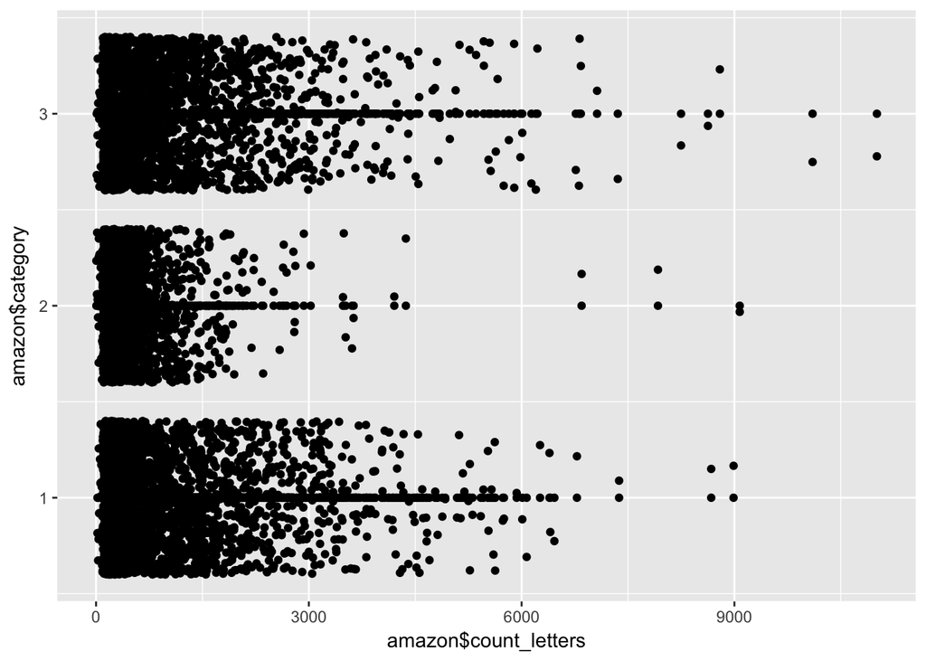

```r
qplot(amazon$count_letters, amazon$category) + geom_point(position = "jitter")
```

```r
amazon$count_read <- stri_count(amazon$to_lower_case, fixed= " read ")
amazon$count_book <- stri_count(amazon$to_lower_case, fixed= " book ")
amazon$count_author <- stri_count(amazon$to_lower_case, fixed= " author ")

amazon$count_movie <- stri_count(amazon$to_lower_case, fixed= " movie")
amazon$count_dvd <- stri_count(amazon$to_lower_case, fixed= "dvd")
```

```r
model_food <- multinom(category ~ count_food_tast + count_food_flavor + count_food_health + count_food_eat + count_read + count_book + count_author + count_movie + count_dvd, data = amazon)
category_pred_2 <- predict(model_food, newdata = amazon)
tapply(category_pred_2 == amazon$category, amazon$train_id, mean)
```

```
##      test     train     valid
##        NA 0.7890741 0.8016667
```

```r
table(y = amazon$category, y_pred = category_pred_2)
```

```
##    y_pred
## y      1    2    3
##   1 1795  590   33
##   2   15 2373    3
##   3   54  801 1536
```

## Part 2: Next, I attempt a different approach using a glmnet for the features I have already extracted.

```r
X <- model.matrix(~ . - 1, data= amazon[,7:15])
y <- amazon$category

X_train <- X[amazon$train_id == "train",]
X_valid <- X[amazon$train_id == "valid",]
y_train <- y[amazon$train_id == "train"]
y_valid <- y[amazon$train_id == "valid"]


model_glmnet <- cv.glmnet(X_train, y_train, alpha=0.9, family="multinomial")
coef(model_glmnet, s = c(model_glmnet$lambda.min, model_glmnet$lambda.1se))
```

```
## $`1`
## 10 x 2 sparse Matrix of class "dgCMatrix"
##                            1          2
## (Intercept)       -0.1934548 -0.1799276
## count_food_tast   -0.2687960  .
## count_food_flavor -0.2410035  .
## count_food_eat     .          .
## count_food_health  .          .
## count_read         2.2138149  2.0960326
## count_book         2.9281267  2.7310877
## count_author       2.3461032  2.1794548
## count_movie        .          .
## count_dvd          .          .
##
## $`2`
## 10 x 2 sparse Matrix of class "dgCMatrix"
##                            1          2
## (Intercept)        0.1002518  0.0810594
## count_food_tast    2.5888849  2.3630194
## count_food_flavor  4.2535700  3.3467705
## count_food_eat     1.8809625  1.6965403
## count_food_health  1.5157883  1.2069894
## count_read        -0.6430406 -0.2540294
## count_book        -2.4182267 -0.7132165
## count_author      -2.6778677 -0.4441646
## count_movie       -1.8588219 -0.6397262
## count_dvd         -1.8456728  .
##
## $`3`
## 10 x 2 sparse Matrix of class "dgCMatrix"
##                             1          2
## (Intercept)        0.09320301  0.0988682
## count_food_tast    .           .
## count_food_flavor  .           .
## count_food_eat    -1.37603367 -0.5922493
## count_food_health -0.54130689 -0.2679177
## count_read         .           .
## count_book         .           .
## count_author       .           .
## count_movie        2.53959902  2.3620280
## count_dvd          3.25893245  2.9239617
```

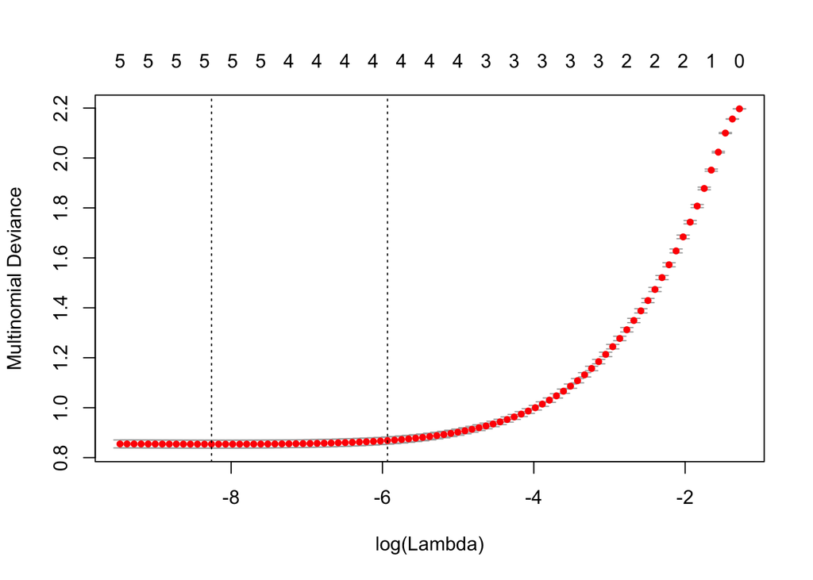

```r
plot(model_glmnet)
```

```r
model_glmnet_pred_1se <- predict(model_glmnet, newx= X, s = "lambda.1se", type="class")
model_glmnet_pred_min <- predict(model_glmnet, newx= X, s = "lambda.min", type="class")


tapply(model_glmnet_pred_1se == amazon$category, amazon$train_id, mean)
```

```
##      test     train     valid
##        NA 0.7892593 0.7983333
```

```r
tapply(model_glmnet_pred_min == amazon$category, amazon$train_id, mean)
```

```
##      test     train     valid
##        NA 0.7885185 0.8011111
```

## Part 3: Finally, I use the xgb train model to fit a one vs. many model with the features that I have selected.

The first thing to do is create new dummy variable columns for categories 1,2,3. Then we run 3 models predicting each respective category. We then use these 3 predictions in our multinom package as we used above in part 1.

```r
amazon$cat_1 <- as.numeric(amazon$category == 1)
amazon$cat_2 <- as.numeric(amazon$category == 2)
amazon$cat_3 <- as.numeric(amazon$category == 3)

y_cat1 <- amazon$cat_1
y_cat1_train <- y_cat1[amazon$train_id == "train"]
y_cat1_valid <- y_cat1[amazon$train_id == "valid"]

y_cat2 <- amazon$cat_2
y_cat2_train <- y_cat2[amazon$train_id == "train"]
y_cat2_valid <- y_cat2[amazon$train_id == "valid"]

y_cat3 <- amazon$cat_3
y_cat3_train <- y_cat3[amazon$train_id == "train"]
y_cat3_valid <- y_cat3[amazon$train_id == "valid"]




data_train_cat1 <- xgb.DMatrix(data=X_train, label = y_cat1_train)
data_valid_cat1 <- xgb.DMatrix(data=X_valid, label = y_cat1_valid)
watchlist_cat1 <- list(train=data_train_cat1, valid=data_valid_cat1)

data_train_cat2 <- xgb.DMatrix(data=X_train, label = y_cat2_train)
data_valid_cat2 <- xgb.DMatrix(data=X_valid, label = y_cat2_valid)
watchlist_cat2 <- list(train=data_train_cat2, valid=data_valid_cat2)

data_train_cat3 <- xgb.DMatrix(data=X_train, label = y_cat3_train)
data_valid_cat3 <- xgb.DMatrix(data=X_valid, label = y_cat3_valid)
watchlist_cat3 <- list(train=data_train_cat3, valid=data_valid_cat3)
```

We then fit 3 xgb.train models, for each category prediction. For class 1, we were able to achieve a 91% class prediction, for class 2, an 88% class prediction and for class 3 an 88% class prediction. Based on our importance matrix, we also note that the health, eat and author keywords were least important across all 3 models.

```r
model_cat_1 <- xgb.train(data=data_train_cat1, max_depth = 4, eta = 0.01, nthread=4, nrounds = 1000, objective = "binary:logistic", watchlist=watchlist_cat1, print_every_n = 100)
model_cat_1_pred <- predict(model_cat_1, newdata= X)
model_cat_1_pred <- as.numeric(model_cat_1_pred > 0.5)
tapply(model_cat_1_pred == y_cat1, amazon$train_id, mean)
```

```
##      test     train     valid
##        NA 0.9035185 0.9116667
```

```r
importance_matrix_cat_1 <- xgb.importance(model = model_cat_1)
importance_matrix_cat_1[,1] <- colnames(X)[as.numeric(importance_matrix_cat_1[[1]])+1]
importance_matrix_cat_1
```

```
##              Feature        Gain      Cover  Frequency
## 1:        count_book 0.629633247 0.18064191 0.22310714
## 2:       count_movie 0.108253729 0.17685590 0.24961815
## 3:        count_read 0.095979669 0.12152733 0.10626227
## 4:   count_food_tast 0.053200416 0.11609888 0.10298931
## 5: count_food_flavor 0.036568043 0.11873906 0.09022474
## 6:         count_dvd 0.033577850 0.11588397 0.10560768
## 7:      count_author 0.029155167 0.08439504 0.04036657
## 8:    count_food_eat 0.007044884 0.04874746 0.02967489
## 9: count_food_health 0.006586994 0.03711046 0.05214925
```

```r
model_cat_2 <- xgb.train(data=data_train_cat2, max_depth = 4, eta = 0.01, nthread=4, nrounds = 1000, objective = "binary:logistic", watchlist=watchlist_cat2, print_every_n = 100)
model_cat_2_pred <- predict(model_cat_2, newdata= X)
model_cat_2_pred <- as.numeric(model_cat_2_pred > 0.5)
tapply(model_cat_2_pred == y_cat2, amazon$train_id, mean)
```

```
##      test     train     valid
##        NA 0.8818519 0.8800000
```

```r
importance_matrix_cat_2 <- xgb.importance(model = model_cat_2)
importance_matrix_cat_2[,1] <- colnames(X)[as.numeric(importance_matrix_cat_2[[1]])+1]
importance_matrix_cat_2
```

```
##              Feature       Gain      Cover  Frequency
## 1:   count_food_tast 0.27792446 0.13708687 0.13312693
## 2: count_food_flavor 0.24961231 0.14307446 0.16811146
## 3:       count_movie 0.17598961 0.15490572 0.15959752
## 4:        count_book 0.16218827 0.17118600 0.15773994
## 5:         count_dvd 0.03994813 0.10087719 0.08312693
## 6:        count_read 0.03609600 0.09049104 0.12647059
## 7:    count_food_eat 0.02710084 0.07312824 0.05743034
## 8: count_food_health 0.01745688 0.05551066 0.05851393
## 9:      count_author 0.01368350 0.07373981 0.05588235
```

```r
model_cat_3 <- xgb.train(data=data_train_cat3, max_depth = 4, eta = 0.01, nthread=4, nrounds = 1000, objective = "binary:logistic", watchlist=watchlist_cat3, print_every_n = 100)
model_cat_3_pred <- predict(model_cat_3, newdata= X)
model_cat_3_pred <- as.numeric(model_cat_3_pred > 0.5)
tapply(model_cat_3_pred == y_cat3, amazon$train_id, mean)
```

```
##      test     train     valid
##        NA 0.8761111 0.8816667
```

```r
importance_matrix_cat_3 <- xgb.importance(model = model_cat_3)
importance_matrix_cat_3[,1] <- colnames(X)[as.numeric(importance_matrix_cat_3[[1]])+1]
importance_matrix_cat_3
```

```
##              Feature        Gain      Cover  Frequency
## 1:       count_movie 0.586054165 0.18699457 0.22751747
## 2:         count_dvd 0.127410945 0.14275317 0.09439798
## 3:        count_book 0.106487029 0.17377586 0.25340818
## 4:   count_food_tast 0.068137554 0.11097251 0.09050292
## 5: count_food_flavor 0.059989249 0.12273878 0.08580593
## 6:        count_read 0.025965160 0.09934119 0.14789781
## 7:    count_food_eat 0.011577948 0.06395755 0.03734678
## 8: count_food_health 0.007483691 0.05084880 0.03127506
## 9:      count_author 0.006894259 0.04861756 0.03184786
```

Finally we blend the one vs. many models into a multinom and see if that improves our validation accuracy. We also look at the confusion matrix to see if there are certain categories we may be underpredicting. We see that our validation accuracy only improved so slightly. It seems as though to get better performance, we may need to add additional features.

```r
model_onevsmany <- multinom(category ~ model_cat_1_pred + model_cat_2_pred + model_cat_3_pred, data = amazon)
model_onevsmany_pred <- predict(model_onevsmany, newdata = amazon)
tapply(model_onevsmany_pred == amazon$category, amazon$train_id, mean)
```

```
##      test     train     valid
##        NA 0.7911111 0.8022222
```

```r
table(y = amazon$category, y_pred = model_onevsmany_pred)
```

```
##    y_pred
## y      1    2    3
##   1 1786  591   41
##   2   12 2376    3
##   3   36  801 1554
```

```r
amazon$category_pred <- model_onevsmany_pred
```

# Submission

The code below assumes that you have added a prediction named `category_pred` to every row of the dataset.

```r
submit <- select(amazon, obs_id, category_pred)
write_csv(submit, "class13_submit.csv")
```

Now, upload this file (ends with “.Rmd”), the HTML output (ends with “.nb.html” or “.html”), and the csv file to GitHub.